# Capstone Price Comparison Project - Code Analysis

Ming Waters

April 26, 2017

### Introduction and Project Goal:

In searching for a Capstone Project, I wanted to find a data set that would answer some common every day questions that will provide value for broad audience. I also wanted a data set that would expose me to a variety of data wrangling requirements. My goal for this project is to develop my R coding skills and use R to perform statistical analysis to answer some useful every day questions.

After exploring various open source data sets, I settled on an opens source price comparison set collected by Alberto Cavallo, co-founder of MIT’s Billion Price Project. Cavallo and team, developed a study to compare thousands of item prices on-line and in store across 10 countries. His study concluded that there were insignificant price differences between on-line and in-store prices. His report did not compare prices by category or if there were price difference when the item was on sale. My project will use a subset of his data, US comparison, to determine if there is a particular type of product, e.g., electronics or office products, that provides better pricing when purchasing on-line or in-store and determine if there is a better strategy to purchasing when the items are on sale. [^1]

#### Project Goal and Benefit:

This project will utilize Cavallo’s price data to determine if there are significant price differences between in-store and online prices for items by category and if there is are any significant differences in prices when the item is on sale. This analysis will benefit many shoppers streamline their choices as they shop for items by category.

#### Data Set:

My project will wrangle and analyze a small subset of Cavallo’s multi-country data. I will focus on the US price comparisons only comparing the in store prices with the Amazon price.

Raw Data file was downloaded from: [Price Data](https://dataverse.harvard.edu/dataset.xhtml?persistentId=doi%3A10.7910%2FDVN%2FXXOUHF)

#### Data Exploration:

After loading the files, I examined the format and the context of each variables to determine which columns contained the needed information to perform my analysis.

```
## Observations: 3,992
## Variables: 19
## $ date_amazon    <fctr> 1/28/2016, 6/8/2016, 6/7/2016, 6/8/2016, 2/25/...
## $ date           <fctr> 1/21/2016, 6/7/2016, 6/7/2016, 6/6/2016, 2/24/...
## $ id             <fctr> 6350009, 1573073, 8801785, 8448381, 8544480030...
## $ price          <dbl> 199.99, 159.99, 9.99, 179.99, 249.99, 29.99, 12...
## $ price_online   <dbl> 169.99, 106.99, 9.99, 179.99, 249.99, 29.99, 12...
## $ price_amazon   <dbl> 156.99, 149.97, 798.00, 159.50, 249.00, 19.88, ...
## $ sale_online    <int> 1, 1, NA, 1, NA, NA, NA, 1, 1, 1, 1, NA, 1, NA,...
## $ product_online <fctr> Actiontec - MyWirelessTV2 Wireless Video Trans...
## $ product_amazon <fctr> Actiontec My Wireless TV WiFi / HDMI Multi-Roo...
## $ merchant       <fctr> Ships from and sold by Amazon.com. Gift-wrap a...
## $ URL            <fctr> http://www.amazon.com/Actiontec-Wireless-WiFi-...
## $ imputed        <int> 1, NA, NA, NA, 1, 1, 1, NA, NA, NA, NA, 1, NA, ...
## $ COMMENTS       <fctr> , , , , , , , , , , , , , , , , , , , , , , , ,
## $ PRICETYPE      <fctr> Regular Price, Regular Price, Regular Price, S...
## $ datediff       <int> 7, 1, 0, 2, 1, 4, 7, 2, 6, 0, 1, 6, 4, 2, 5, 3,...
## $ cat_id         <int> 900, 900, 900, 900, 900, 900, 900, 900, 900, 90...
## $ category       <fctr> Electronics, Electronics, Electronics, Electro...
## $ retailer_id    <int> 40, 40, 40, 40, 40, 40, 40, 40, 40, 40, 40, 40,...
## $ retailer_s     <fctr> USA_40, USA_40, USA_40, USA_40, USA_40, USA_40...
```

```
##  [1] "date_amazon"    "date"           "id"             "price"
##  [5] "price_online"   "price_amazon"   "sale_online"    "product_online"
##  [9] "product_amazon" "merchant"       "URL"            "imputed"
## [13] "COMMENTS"       "PRICETYPE"      "datediff"       "cat_id"
## [17] "category"       "retailer_id"    "retailer_s"
```

Initial analysis of the raw data shows the variables and observation in the format needed to manage with R, variables are in columns. To perform my analysis, I will need the following variables:

- price – price in store
- id – item number
- price_amazon – price on amazon
- sale_online – the item was on sale online
- PRICETYPE – if the item was on sale in store
- category – groupings of product type (electronics, office supply, etc.)

My analysis will rely on the price differences between price in-store and price on-line so I need to calculate a new field called, “delta.”

After inspecting the deltas, I realized that the price deltas were misleading since deltas for high cost values were more significant than deltas for low cost values. Most customers will value saving $1 for a $2 item as much as saving $10 for $100 item, therefore, I decided to create another field p difference, to weigh high price deltas equal to low price deltas.

```r
w_price <- mutate(w_price, "p_difference" = (delta/price))
```

Now that I have created the needed variables, I inspect the new table to see how to set up my analysis. Upon inspection I see a obvious error in price column. On row 1614, the id number matches the price in-store. The price is significantly higher than the on-line. I need to remove these errors if I want to perform a good analysis.

I create a vector that will capture the rows that have matching id and price values. I think inspect the vector to determine how many rows I will be removing as a final check.

```
##  int [1:2] 1034 1614
```

Only two rows contain the error so I will remove the data errors.

#### Data Entry Errors and Outliers:

Upon further inspection, it was evident that there were several large errors embedded in the data. Data errors include –

- Product ID transferring into In-Store Prices
- Errors in decimal placement - ex – 6.99 (in-store) but typed as 69.9 (amazon)
- Errors in data entry – ex – Door has online price 2,130 and in-store price of 3.97
- There were subtle errors where some items did appear to be erroneous but differences and product type were unclear since Amazon may charge higher prices for small items to compensate for shipping and handling

The data set contained over 3900 rows so manual inspection of each item was not feasible.

I decided to use ggplots to visualize thee data by categories to start my decisions around what delta ranges have gross errors.

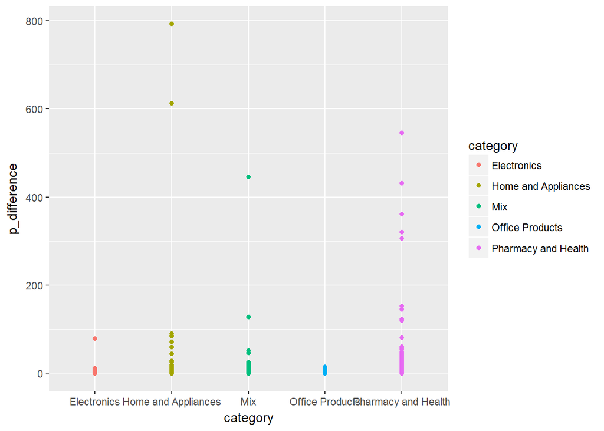

Inspection of the plot shows reasonable clustering around the difference value under 100. If I remove all values exceeding 100, I can remove the majority of my obvious data entry errors.

```
##  int [1:16] 879 885 889 939 949 975 990 1010 1076 1107 ...
```

The results shows 16 values needing removal. After removing the values, I plot the data again by category to determine if the outliers were removed and to view the new distribution of percent differences

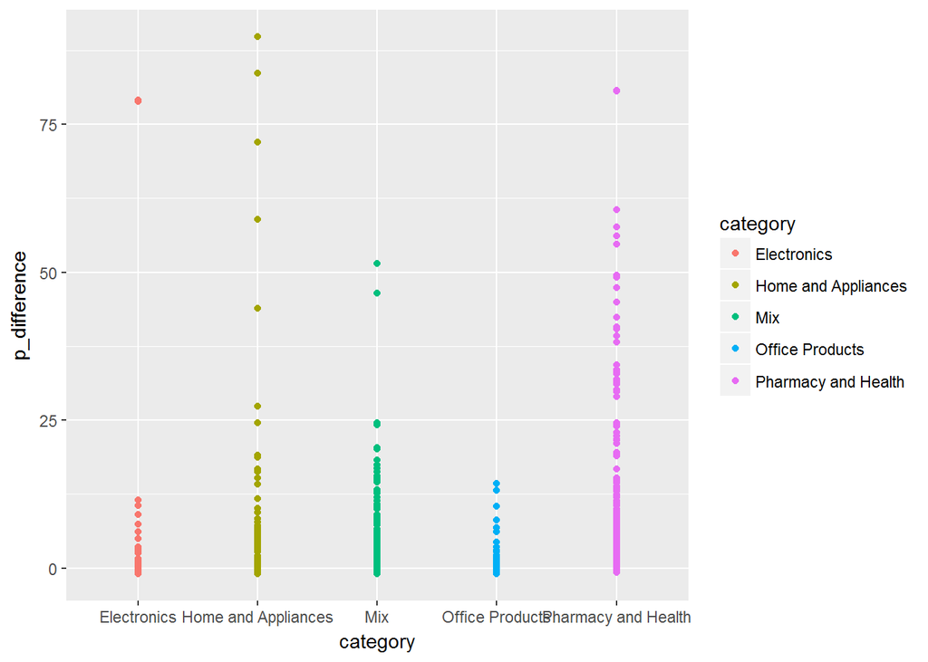

The plot shows that there are still a few extreme outliers that look to be outside the normal range.

To begin my analysis for distribution and outliers, I need to split the data frame by category.

```r
# Create data frames by category type
electronics_set <- filter(w_price2, category == "Electronics")
home_app <- filter(w_price2, category == "Home and Appliances")
mix <- filter(w_price2, category == "Mix")
office <- filter(w_price2, category =="Office Products")
pharm_health <- filter(w_price2, category == "Pharmacy and Health")
```

This split the data set into 5 data frames:

- Electronics Set “electronics_set”
- Home Appliances “home_app”
- Mix of Items “mix”
- Office Products “office”
- Pharmacy and Health Items “pharm_health”

I want to view the distributions of each of the categories to visually inspect normality and calculate the mean.

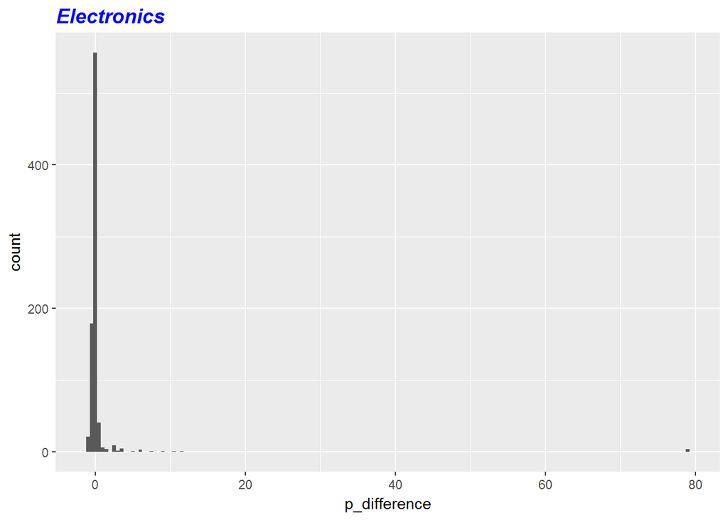

```
##     Min.  1st Qu.   Median     Mean  3rd Qu.     Max.
## -0.98920 -0.23610 -0.04924  0.40260  0.00000 79.08000
```

I repeat this exercise for each of the categories.

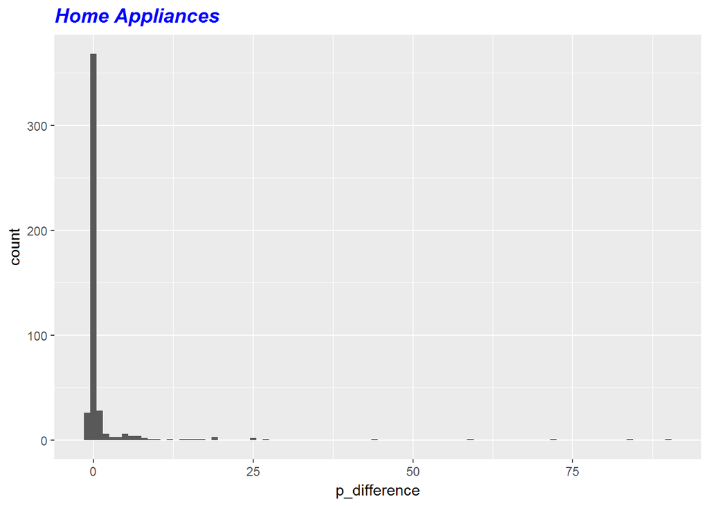

```
##    Min. 1st Qu.  Median    Mean 3rd Qu.    Max.
## -0.9953 -0.1000  0.0000  1.4990  0.1252 89.7900
```

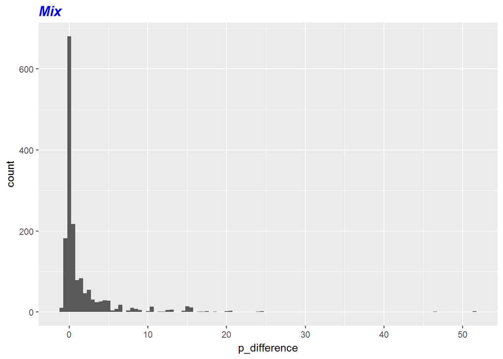

```
##     Min.  1st Qu.   Median     Mean  3rd Qu.     Max.
## -0.97580 -0.09099  0.16520  1.57000  1.50200 51.51000
```

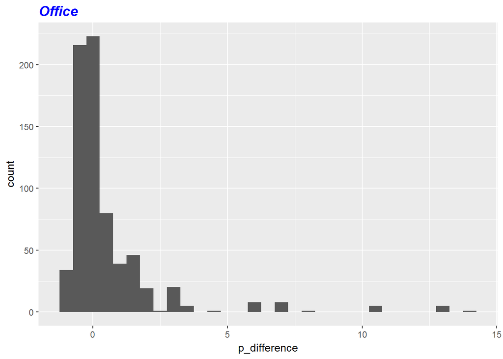

```
##    Min. 1st Qu.  Median    Mean 3rd Qu.    Max.
## -0.9600 -0.3433 -0.1112  0.5264  0.5104 14.2400
```

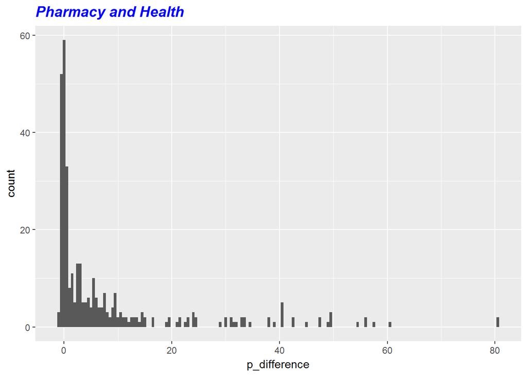

```
##    Min. 1st Qu.  Median    Mean 3rd Qu.    Max.
## -0.8004 -0.1328  2.0250  8.0040  8.8560 80.7400
```

The histograms for all the categories do not appear to follow a normal distribution. In addition, each category has some extreme outliers. I performed a quick Sharpiro-Wilk Normality test just to validate.

```
##
##  Shapiro-Wilk normality test
##
## data:  electronics_set$p_difference
## W = 0.087593, p-value < 2.2e-16
```

```
##
##  Shapiro-Wilk normality test
##
## data:  home_app$p_difference
## W = 0.21147, p-value < 2.2e-16
```

```
##
##  Shapiro-Wilk normality test
##
## data:  mix$p_difference
## W = 0.48746, p-value < 2.2e-16
```

```
##
##  Shapiro-Wilk normality test
##
## data:  office$p_difference
## W = 0.54757, p-value < 2.2e-16
```

```
##
##  Shapiro-Wilk normality test
##
## data:  pharm_health$p_difference
## W = 0.64011, p-value < 2.2e-16
```

Clearly the p-value shows that we can reject the null hypothesis that the data is normal.

Since the data is non-normal, I need to find a method to remove outliers. Traditional tests such as Grubbs or Chi square test will not apply. I can use my data set’s interquartile (IQR) range to determine points as ouliers. Removing outliers beyond 1.5*IQR will be a good baseline. I also need to verify the calculated ranges to ensure they make “practical” sense as outliers.

```
##     Min.  1st Qu.   Median     Mean  3rd Qu.     Max.
## -0.98920 -0.23610 -0.04924  0.40260  0.00000 79.08000
```

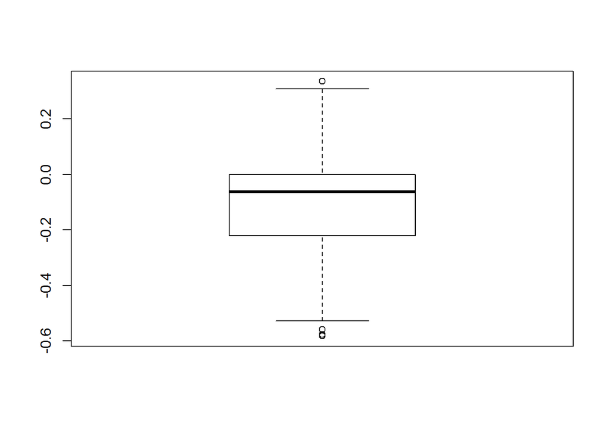

```
##    Min. 1st Qu.  Median    Mean 3rd Qu.    Max.
## -0.9953 -0.1000  0.0000  1.4990  0.1252 89.7900
```

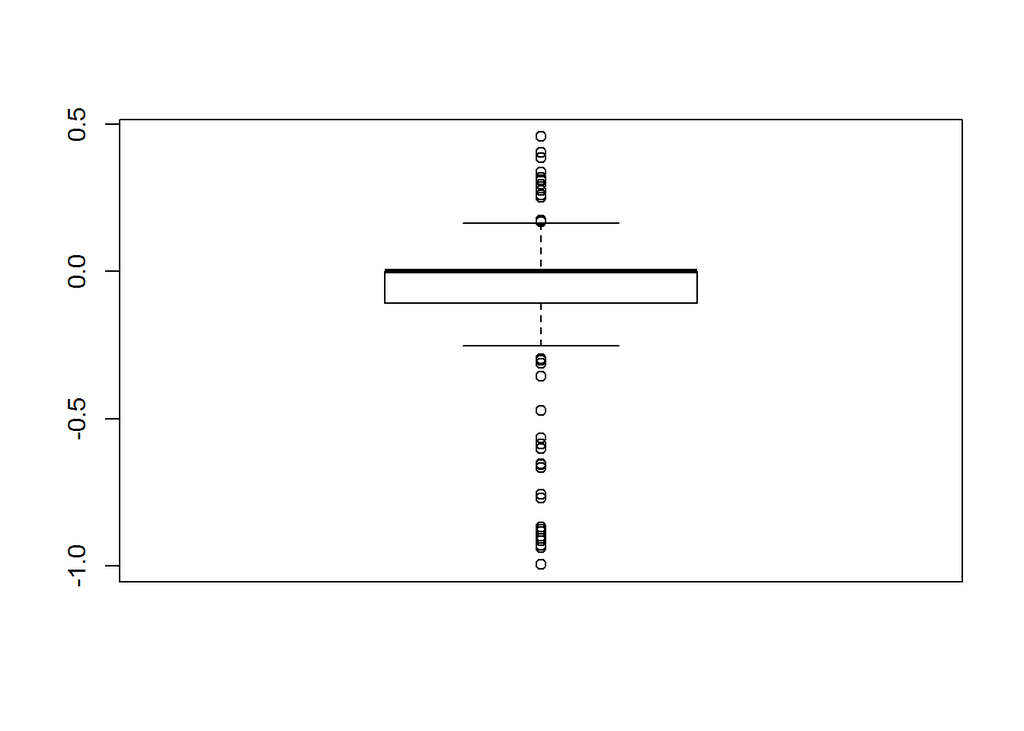

```
##     Min.  1st Qu.   Median     Mean  3rd Qu.     Max.
## -0.97580 -0.09099  0.16520  1.57000  1.50200 51.51000
```

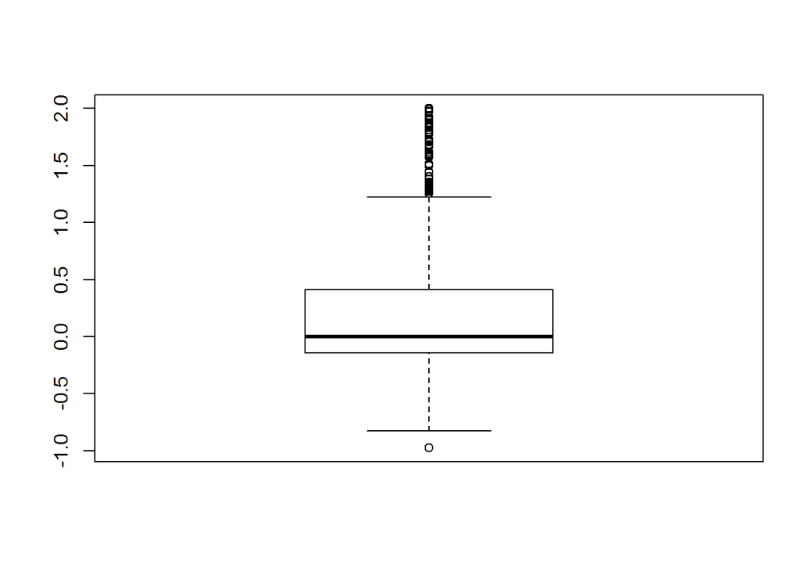

```
##    Min. 1st Qu.  Median    Mean 3rd Qu.    Max.
## -0.9600 -0.3433 -0.1112  0.5264  0.5104 14.2400
```

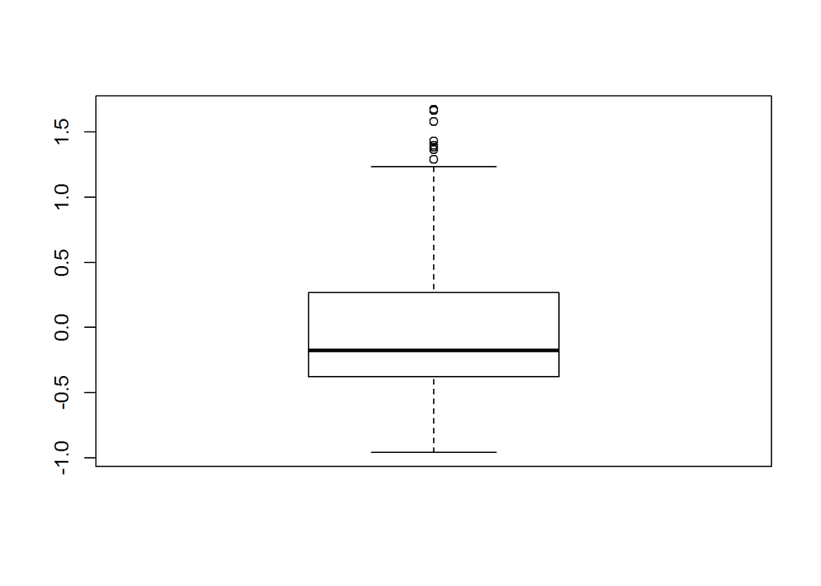

```
##    Min. 1st Qu.  Median    Mean 3rd Qu.    Max.
## -0.8004 -0.1328  2.0250  8.0040  8.8560 80.7400
```

Now that I removed outliers from each set, I plot histograms of each of the categories to inspect the distributions of each category.

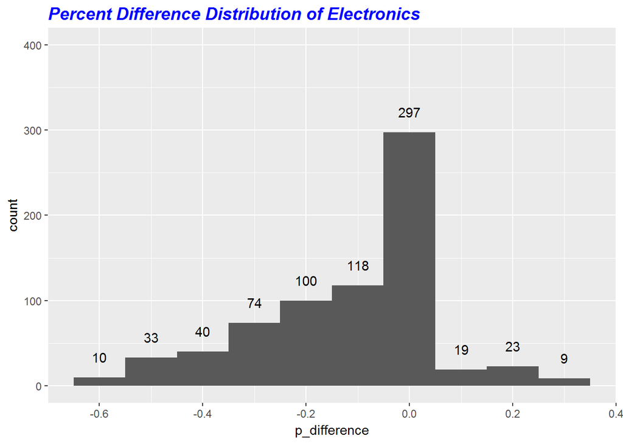

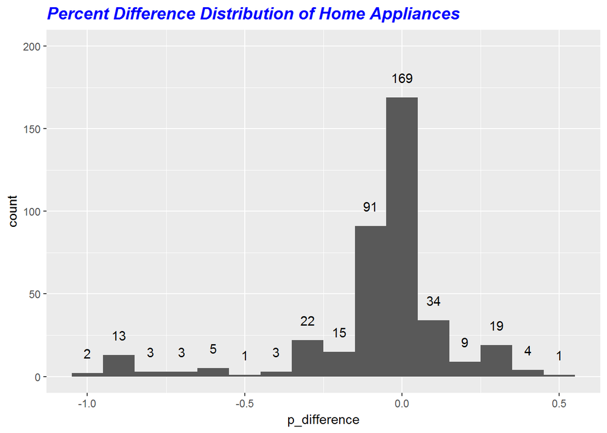

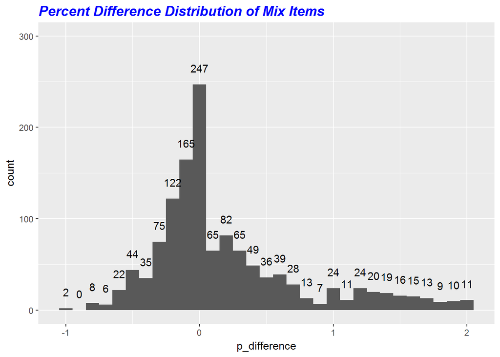

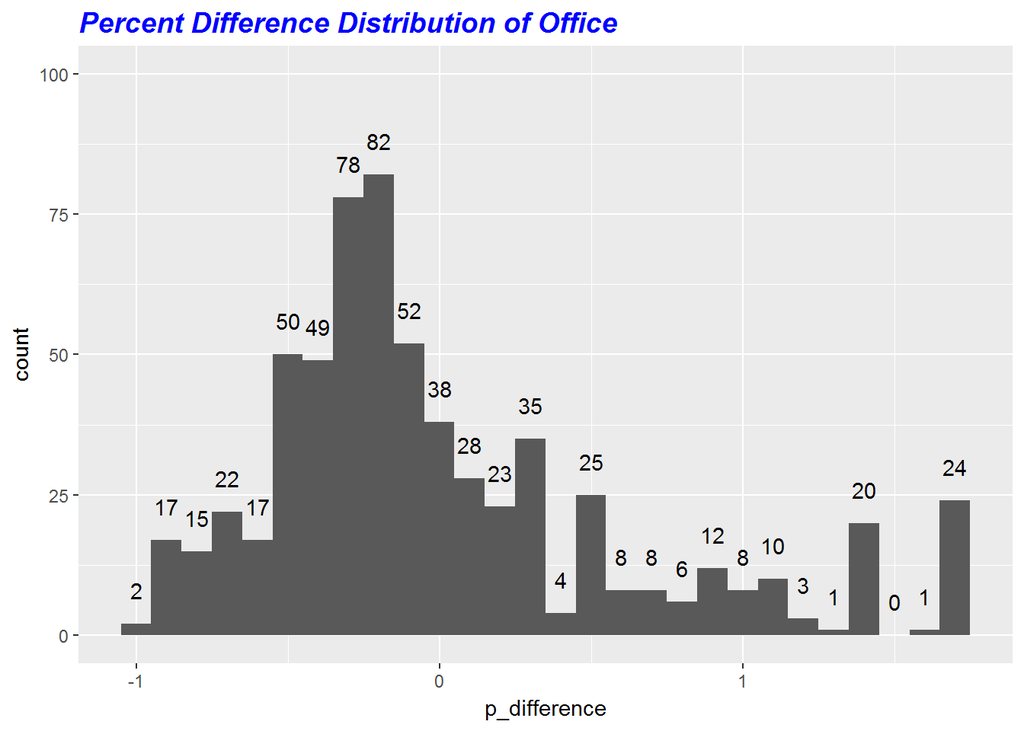

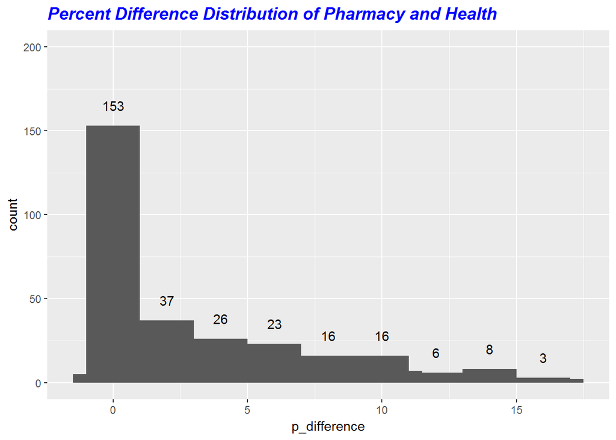

The histograms show that even with removal of significant outliers the data is still skewed with a large range of values. Ideally the next step would be to perform a multi-factor analysis of variance (ANOVA) to determine if there are significance differences between the categories or a logistic regression to see which category correlates the best to percent difference. I did not pursue these traditional statistical tests as the data was non-normal and may still contain data entry errors.

Instead, I performed a simple analysis that analyzed the percentage of times the data showed better pricing on-line versus in-store. To perform this analysis, I created a new column that created a value of 1 if the p_difference was 0 or greater and 0 if the value was less than zero. Negative percent difference values show better prices on-line. I will then take the mean to determine what percentage of time the values showed better pricing in-store by category.

First, I recombined my categories to form a single data set and then create a new column called bias, that assigns a value of 0 if the p_difference is less than zero and 1 if greater or equal to zero.

```r
# Recombind the various categories into one data frame
w_price3 <- rbind(electronics_set, home_app, pharm_health, mix, office)

w_price4 <- mutate(w_price3, bias = ifelse(p_difference  >= 0, 1, 0))
```

Then I calculated the mean by category.

```
## [1] 0.2365145
```

```
## [1] 0.5101523
```

```
## [1] 0.5304212
```

```
## [1] 0.369906
```

From the mean values you can see the percentage of time in-store has better or neutral pricing versus on-line.

- Electronics = 23.65% better pricing in-store
- Home Products = 51.02% better pricing in-store
- Mix Products = 53.04% better pricing in-store
- Office Products = 36.99% better pricing in-store

Thus, I would to my client it would be better to purchase electronics and office products on-line.

#### Analyzing if sale price or regular price shows better value in-store or on-line:

The next analysis will determine what percentage of time the data showed better pricing in the store when the item was on sale or regular priced. I inspected the variables, PRICETYPE and sale_online.

PRICETYPE contains the values Regular Price and Sale/Discounted Price. The variable also contains missing values. The sale_online variable contains a value of 1 if the price is on sale and NA if the price is regular price. Based on the values there are four conditions that item can have.

- Cat 1 = regular price online, regular price in store
- Cat 2 = sale online, regular price in store
- Cat 3 = regular price online, sale price in store
- Cat 4 = sale price online, sale price in store

I need to create a variable, “cat_price” that will evaluate the conditions in the PRICETYPE and sale_online variables then create a character value that specifies that condition.

```r
w_price4 %>%
  mutate(cat_price = ifelse(PRICETYPE == 'Regular Price',
                            ifelse(is.na(sale_online), 'Cat 1', 'Cat 2'),
                            ifelse(PRICETYPE == 'Sale/Discounted Price',
                                   ifelse(is.na(sale_online), 'Cat 3', 'Cat 4'),
                                   NA))) -> w_price5
```

I include a statement to assign an NA if the PRICETYPE is missing. After creating the new column, I graph the categories to see the various distributions.

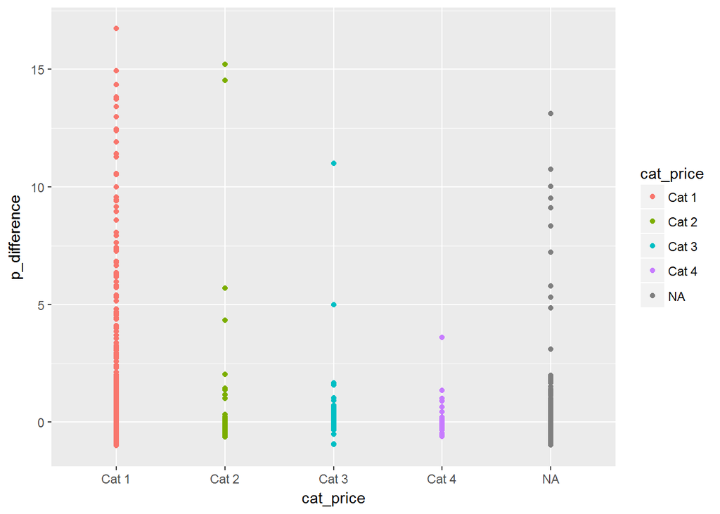

There seems to be quite a bit of NA but at this point, I cannot make any logical assumptions with the data set so I decide to discard the NA.I pursue the same approach as before and split the data set by category type “cat_price” and calculate the bias mean by category type.

The mean of the bias values tells me which Category provides the best pricing in the store.

- Cat 1 = 0.4309091
- Cat 2 = 0.2614379
- Cat 3 = 0.6818182
- Cat 4 = 0.3818182

The mean of the categories shows that only Category 3 provides better pricing in the store the majority of the time when the price is on sale in the store and regular price on-line.

It is interesting that when the total data set was analyzed and the price bias was not broken up by categories, it was much better to buy items on-line versus in the store unless the item was only on sale in the store.

Overall I would recommend my client purchase or evaluate purchasing items on-line to receive better price.

[^1]: Cavallo, Alberto, 2016, “Are-Online and Offline Prices Similar? Evidence from Large Multi-Channel Retailers”- American Economic Review doi:10.7910/DVN/XXOUHF, Harvard Dataverse, V4